# Class 3

## 3.8 Making animations

Animated plots can be a great way to illustrate your data in presentations. The R package `gganimate` lets you do just that.

Here is an example showing how to use it.

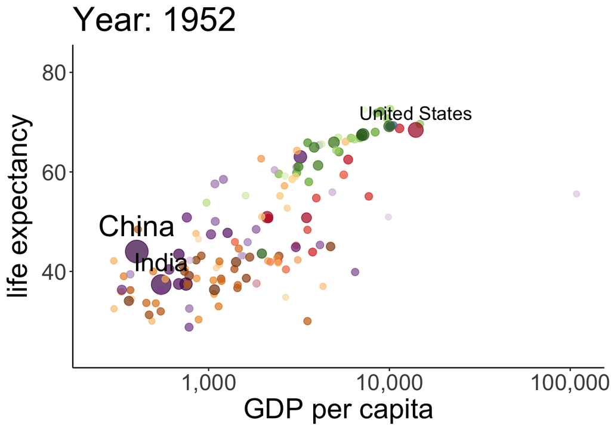

```r
ggplot(data = gapminder,
       mapping = aes(x = gdpPercap,
                     y = lifeExp,
                     size = pop,
                     colour = country)) +
  geom_point(alpha = 0.7, show.legend = FALSE) +
  geom_text(data = gapminder %>%
              filter(country %in% c("United States", "China", "India")),
            mapping = aes(label = country),
            color = "black",
            vjust = -0.75,
            show.legend = FALSE) +
  scale_colour_manual(values = country_colors) +
  scale_size(range = c(2, 12)) +
  scale_x_log10(breaks = c(1e3, 1e4, 1e5),
                labels = c("1,000", "10,000", "100,000")) +
  theme_classic() +
  theme(text = element_text(size = 23)) +
  # Here come the gganimate specific bits
  labs(title = "Year: {frame_time}", x = "GDP per capita", y = "life expectancy") +
  transition_time(year) +
  ease_aes("linear")
# anim_save(filename = "figures/life_gdp_animation.gif") # to save the animation
```

This takes a while to run but it’s worth the wait. The plot shows the relationship between GDP per capita (on the x-axis) and life expectancy (on the y-axis) changes across different years for the countries of different continents. The size of each dot represents the population size of the respective country. And different countries are shown in different colors. This animation is not super useful yet in that we don’t know which continents and countries the different dots represent. I’ve added a label to the United States, China, and India.

Note how little is required to define the `gganimate`-specific information! The `{frame_time}` variable changes the title for each frame. The `transition_time()` variable is set to `year`, and the kind of transition is set as ‘linear’ in `ease_aes()`. I’ve saved the animation as a gif in the figures folder. We won’t have time to go into more detail here but I encourage you to play around with `gganimate`. It’s fun, looks cool, and (if done well) makes for a great slide in your next presentation!

## 3.9 Shiny apps

The package [`shiny`](https://shiny.rstudio.com/) makes it relatively easy to create interactive plots that can be hosted online. Here is a [gallery](https://shiny.rstudio.com/gallery/) with some examples.

## 3.10 Defining snippets

Here are some snippets I use:

```r
snippet sngg
    ggplot(data = ${1:data},
           mapping = aes(${2:aes})) +
        ${0}

snippet sndf
    ${1:data} = ${1:data} %>%
        ${0}
```

In RStudio, you can change and add snippets by going to Tools –> Global Options… –> Code –> Edit Snippets. Make sure to set the tick mark in front of Enable Code Snippets (see Figure 3.8). ).

[figure not shown]

Figure 3.8: Enable code snippets.

To edit code snippets faster, run this command from the `usethis` package. Make sure to install the package first if you don’t have it yet.

```r
# install.packages("usethis")
usethis::edit_rstudio_snippets()
```

This command opens up a separate tab in RStudio called `r.snippets` so that you can make new snippets and adapt old ones more quickly. Take a look at the snippets that RStudio already comes with. And then, make some new ones! By using snippets you will be able to avoid typing the same code over and over again, and you won’t have to memorize as much, too.

## 3.11 Additional resources

### 3.11.1 Cheatsheets

- shiny –> interactive plots

### 3.11.2 Data camp courses

- [shiny](https://www.datacamp.com/courses/building-web-applications-in-r-with-shiny-case-studies)

### 3.11.3 Books and chapters

- [R for Data Science book](http://r4ds.had.co.nz/)
  - [Data visualization](http://r4ds.had.co.nz/data-visualisation.html)
  - [Graphics for communication](http://r4ds.had.co.nz/graphics-for-communication.html)
- [Data Visualization – A practical introduction (by Kieran Healy)](http://socviz.co/)
  - [Refine your plots](http://socviz.co/refineplots.html#refineplots)

### 3.11.4 Misc

- [ggplot2 extensions](https://z3tt.github.io/exciting-extensions/slides.html?s=09#/layers) –> gallery of ggplot2 extension packages
- [ggplot2 gui](https://github.com/dreamRs/esquisse) –> ggplot2 extension package
- [ggplot2 visualizations with code](http://r-statistics.co/Top50-Ggplot2-Visualizations-MasterList-R-Code.html) –> gallery of plots with code
- [Color brewer](http://colorbrewer2.org/) –> for finding colors
- [CVSimulator](https://asada.website/cvsimulator/e/) –> for testing colorblind-friendliness
- [shiny apps examples](https://sites.psu.edu/shinyapps/) –> shiny apps examples that focus on statistics teaching (made by students at PennState)